# Çok Düzeyli Modeller - Tanıtım

Burak AYDIN  
7 OCAK 2020

### İçerik

1. **Nicel veriler neden önemli?**
2. Korelasyon -> Regresyon -> Çok düzeyli modeller (ÇDM)
3. Çok düzeyli modellerin gerekliliği - Örnekler
4. Dikkat edilmesi gereken noktalar

### Nicel Veriler

- Nicel veri: sayısal değerle ifade edilen veriler.Nicel veriler neden bu kadar hayatımızda ve önemli? Örneğin PISA?

[figure not shown]

### Galileo ve Galton

[figure not shown]

[figure not shown]

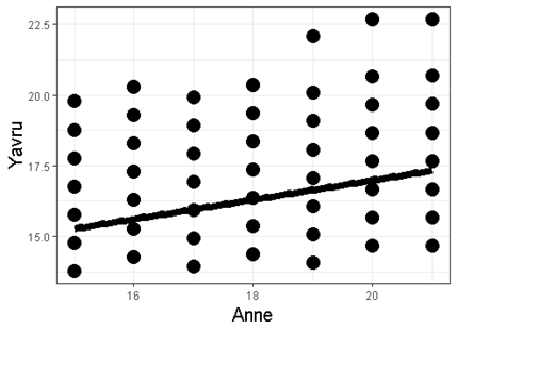

### Korelasyon

\[ \rho(x,y) \]

\[ cor(x,y)=\frac{\frac{\sum_{i=1}^n ((x_i - \hat{x})((y_i - \hat{y}))}{n-1}}{s_x s_y} \]

- Peki sadece iki değişkenin arasındaki doğrusal ilişkiyi anlamak yeterli mi?

### Regresyon

\[ Y_i=\beta_0 + \beta_1 X_{1i} + \beta_2 X_{2i} + ... + e_i \]

- Ne kadar yaygın?
- Sosyal bilimlerde ve eğitim araştırmalarında en çok atıf alan makaleler/araştırmacılar?

### Regresyon örnekleri

- Akademik başarıyı tahmin edebilir miyiz?
- İlkokulda sınıf atlamanın akademik başarıda etkisi var mı? [1]
- İyi argüman geliştirmeyi etkileyen faktörler nelerdir?

### İçerik

1. Nicel veriler neden önemli?
2. **Korelasyon -> Regresyon -> Çok düzeyli modeller (ÇDM)**
3. Çok düzeyli modellerin gerekliliği - Örnekler
4. Dikkat edilmesi gereken noktalar

### Regresyonda önemli noktalar

- Yordayıcı değişken seçimi
- Artıklar ve etkili gözlemler
- Doğrusal olmayan regresyon
- **Korelasyon gösteren veya bağımsız olmayan hata terimleri (BOHT)**

### BOHT durumları

1. Verilerin kümeli yapılardan gelmesi. Peki eğitim alanında hangi kümelerden bahsedebiliriz?
2. Boylamsal veriler.

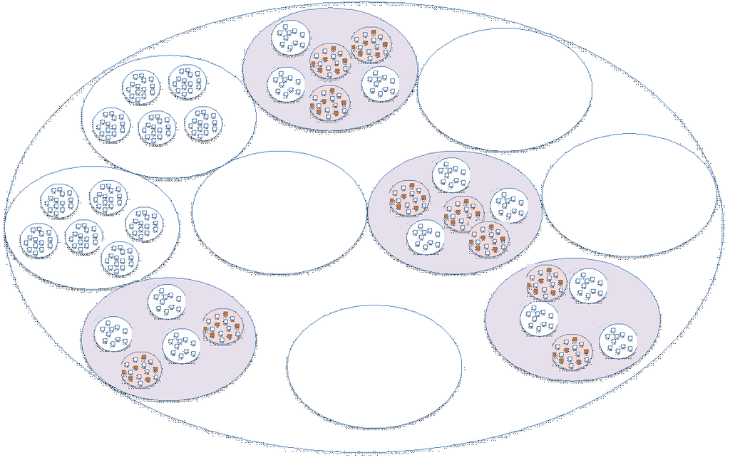

### İçerik

1. Nicel veriler neden önemli?
2. Korelasyon -> Regresyon -> Çok düzeyli modeller (ÇDM)
3. **Çok düzeyli modellerin gerekliliği - Örnekler**
4. Dikkat edilmesi gereken noktalar

### Çok düzeyli modellerin gerekliliği

1. BOHT durumunda geçerli sonuçlara ulaşmak
2. Bağlamsal etkileri görmek
3. Varyansın veya modelin düzeyler arası nasıl farklılık gösterdiğini anlamak.

### 1. BOHT durumunda geçerli sonuçlara ulaşmak - Örnek

- Örnek: Öğrencilerin davranış bozukluklarını azaltmak üzere hazırlanmış bir program (müdahele) etkili mi?
- BOHT durumu: Öğrencilerin okullarda kümelenmiş olması.
- Çok düzeyli model yerine geleneksel regresyon kullanırsak sonucu ne olabilir?

### 2. Bağlamsal etkileri görmek

- Bağlamsal etki nedir? Bir kümede ortalamaya göre nerde yer aldığımız önemli midir?
- Örnek: Büyük balık küçük göl etkisi [2]

### 3. Düzeyler arası varyans ve modeller

- PISA başarısını etkileyen faktörler?
- Farklı düzeylerde farklı yapısal modeller

### İçerik

1. Nicel veriler neden önemli?
2. Korelasyon -> Regresyon -> Çok düzeyli modeller (ÇDM)
3. Çok düzeyli modellerin gerekliliği - Örnekler
4. **Dikkat edilmesi gereken noktalar**

### Nelere dikkat edilmeli?

- Sabit ve rassal etkiler dikkatlice incelendi mi?
- Hata terimleri normal dağılım gösteriyor mu?
- Ortak etki veya doğrusal olmayan bağlantı var mı?
- Örneklem büyüklüğü yeterli mi? (İkinci düzey örneklemi azsa ne yapılabilir?)
- Ağırlıklandırma?
- Sıradışı/etkili gözlemler?
- Kayıp veriler?

### Referanslar

- [1] Kretschmann, J., Vock, M., & Lüdtke, O. (2014). Acceleration in elementary school: Using propensity score matching to estimate the effects on academic achievement. Journal of educational psychology, 106(4), 1080.
- [2] Marsh, H. W., Trautwein, U., Lüdtke, O., Baumert, J., & Köller, O. (2007). The big-fish-little-pond effect: Persistent negative effects of selective high schools on self-concept after graduation. American Educational Research Journal, 44(3), 631-669.
- Snijders ve Bosker (2012), Finch, Bolin ve Kelley (2014), Pinheiro ve Bates (2000), West, Welch ve Galecki (2015)

### Soru-cevap

- Teşekkürler